# CVD Case Study

Cardiovascular disease (CVD) is a leading cause of death globally. It affects millions of people annually. It encompasses a range of conditions affecting the heart and blood vessels, such as heart attacks, strokes, and hypertension.

The goal is to analyse the Cardiovascular Disease Dataset from kaggle.com and identify key factors contributing to cardiovascular disease risk, predict heart disease using classification techniques and discuss findings.

The Cardiovascular Disease Dataset contains various patient health metrics, including age, gender, height, weight, blood pressure (systolic and diastolic), cholesterol, glucose and lifestyle factors such as smoking, alcohol consumption, and physical activity.

### Hypothesis:

Higher cholesterol levels, increased age, elevated blood pressure, higher body mass index (BMI), higher glucose levels, diabetes, lifestyle choices (smoking, alcohol, physical activity) are strong predictors of cardiovascular disease.

### Analyses:

1. Examine the relationship between cholesterol levels and the presence of cardiovascular desease
2. Compare the prevalence of cardiovascular disease across different age groups, between males and females
3. Investigate the correlation between systolic blood pressure and cardiovascular disease prevalence
4. Calculate BMI from height and weight data ana analyze its association with cardiovascular disease
5. Explore the relationship between glucose levels and cardiovascular disease status
6. Compare the prevalence of cardiovascular disease among individuals who smoke, drink alcohol, physically active vs. those who do not
7. Conclusion of all findings

## Steps of the Case Study

1. Import Libraries and load the Dataset
2. Data Information and Exploratory Data Analysis (EDA)
3. Machine Leaning Models (building, evaluating and interpretating of findings)
4. Conclusion and Recommendation

### Data preprocessing and EDA

1. Handling missing data and removing duplicates
2. Removing and correcting errorneous outliers (unrealistic blood pressure values)
3. Additing new features and categorizing into groups for more detailed analysis of its effect on cardiovascular disease

### Methodology

Classification algorithms used

1. Logistic Regression to understand the impact of individual features (presence or absence of heart disease)
2. Random Forest to capture complex nonlinear relationships in the data which might improve prediction accuracy

### Model evaluation

1. Used accuracy, precision, recall, F1 score, and ROC-AUC to assess model performance
2. Performed cross-validation to ensure the robustness of results
3. Plotted ROC curves to visualize model performance

# 1. Import Libraries and Load the Dataset

```python
# Import necessary libraries to evaluate the data and feed the models

# for data manipulation
import pandas as pd # for data analysis
import numpy as np #for numerical data

# for data visualization
import matplotlib.pyplot as plt # for data visualization
import seaborn as sns # for statistical plot
import pylab as plot

%matplotlib inline
import math
import warnings # to suppress any warnings
warnings.simplefilter(action='ignore', category=FutureWarning)

# machine learning models
from sklearn.impute import SimpleImputer
from sklearn.preprocessing import StandardScaler

from sklearn.model_selection import train_test_split, cross_val_score
from sklearn.linear_model import LogisticRegression
from sklearn.tree import DecisionTreeClassifier
from sklearn.ensemble import RandomForestClassifier

from sklearn import metrics # for getting model performance
from sklearn.metrics import classification_report, confusion_matrix, roc_curve, auc
from sklearn.metrics import accuracy_score, precision_score, recall_score, f1_score
```

# 2. Data Information and EDA

```python
df = pd.read_csv(r'C:\Users\Хамида\Downloads\cardio_train.csv', sep=';')
```

```python
# creating a copy of the dataset
data=df.copy()
df
```

|  | id | age | gender | height | weight | ap_hi | ap_lo | cholesterol | gluc | smoke | alco | active | cardio |
| --- | --- | --- | --- | --- | --- | --- | --- | --- | --- | --- | --- | --- | --- |
| 0 | 0 | 18393 | 2 | 168 | 62.0 | 110 | 80 | 1 | 1 | 0 | 0 | 1 | 0 |
| 1 | 1 | 20228 | 1 | 156 | 85.0 | 140 | 90 | 3 | 1 | 0 | 0 | 1 | 1 |
| 2 | 2 | 18857 | 1 | 165 | 64.0 | 130 | 70 | 3 | 1 | 0 | 0 | 0 | 1 |
| 3 | 3 | 17623 | 2 | 169 | 82.0 | 150 | 100 | 1 | 1 | 0 | 0 | 1 | 1 |
| 4 | 4 | 17474 | 1 | 156 | 56.0 | 100 | 60 | 1 | 1 | 0 | 0 | 0 | 0 |
| ... | ... | ... | ... | ... | ... | ... | ... | ... | ... | ... | ... | ... | ... |
| 69995 | 99993 | 19240 | 2 | 168 | 76.0 | 120 | 80 | 1 | 1 | 1 | 0 | 1 | 0 |
| 69996 | 99995 | 22601 | 1 | 158 | 126.0 | 140 | 90 | 2 | 2 | 0 | 0 | 1 | 1 |
| 69997 | 99996 | 19066 | 2 | 183 | 105.0 | 180 | 90 | 3 | 1 | 0 | 1 | 0 | 1 |
| 69998 | 99998 | 22431 | 1 | 163 | 72.0 | 135 | 80 | 1 | 2 | 0 | 0 | 0 | 1 |
| 69999 | 99999 | 20540 | 1 | 170 | 72.0 | 120 | 80 | 2 | 1 | 0 | 0 | 1 | 0 |

70000 rows × 13 columns

```python
df.set_index("id" , inplace=True)
```

```python
df
```

| id | age | gender | height | weight | ap_hi | ap_lo | cholesterol | gluc | smoke | alco | active | cardio |
| --- | --- | --- | --- | --- | --- | --- | --- | --- | --- | --- | --- | --- |
| 0 | 18393 | 2 | 168 | 62.0 | 110 | 80 | 1 | 1 | 0 | 0 | 1 | 0 |
| 1 | 20228 | 1 | 156 | 85.0 | 140 | 90 | 3 | 1 | 0 | 0 | 1 | 1 |
| 2 | 18857 | 1 | 165 | 64.0 | 130 | 70 | 3 | 1 | 0 | 0 | 0 | 1 |
| 3 | 17623 | 2 | 169 | 82.0 | 150 | 100 | 1 | 1 | 0 | 0 | 1 | 1 |
| 4 | 17474 | 1 | 156 | 56.0 | 100 | 60 | 1 | 1 | 0 | 0 | 0 | 0 |
| ... | ... | ... | ... | ... | ... | ... | ... | ... | ... | ... | ... | ... |
| 99993 | 19240 | 2 | 168 | 76.0 | 120 | 80 | 1 | 1 | 1 | 0 | 1 | 0 |
| 99995 | 22601 | 1 | 158 | 126.0 | 140 | 90 | 2 | 2 | 0 | 0 | 1 | 1 |
| 99996 | 19066 | 2 | 183 | 105.0 | 180 | 90 | 3 | 1 | 0 | 1 | 0 | 1 |
| 99998 | 22431 | 1 | 163 | 72.0 | 135 | 80 | 1 | 2 | 0 | 0 | 0 | 1 |
| 99999 | 20540 | 1 | 170 | 72.0 | 120 | 80 | 2 | 1 | 0 | 0 | 1 | 0 |

70000 rows × 12 columns

```python
df.head()
```

| id | age | gender | height | weight | ap_hi | ap_lo | cholesterol | gluc | smoke | alco | active | cardio |
| --- | --- | --- | --- | --- | --- | --- | --- | --- | --- | --- | --- | --- |
| 0 | 18393 | 2 | 168 | 62.0 | 110 | 80 | 1 | 1 | 0 | 0 | 1 | 0 |
| 1 | 20228 | 1 | 156 | 85.0 | 140 | 90 | 3 | 1 | 0 | 0 | 1 | 1 |
| 2 | 18857 | 1 | 165 | 64.0 | 130 | 70 | 3 | 1 | 0 | 0 | 0 | 1 |
| 3 | 17623 | 2 | 169 | 82.0 | 150 | 100 | 1 | 1 | 0 | 0 | 1 | 1 |
| 4 | 17474 | 1 | 156 | 56.0 | 100 | 60 | 1 | 1 | 0 | 0 | 0 | 0 |

```python
df.tail()
```

| id | age | gender | height | weight | ap_hi | ap_lo | cholesterol | gluc | smoke | alco | active | cardio |
| --- | --- | --- | --- | --- | --- | --- | --- | --- | --- | --- | --- | --- |
| 99993 | 19240 | 2 | 168 | 76.0 | 120 | 80 | 1 | 1 | 1 | 0 | 1 | 0 |
| 99995 | 22601 | 1 | 158 | 126.0 | 140 | 90 | 2 | 2 | 0 | 0 | 1 | 1 |
| 99996 | 19066 | 2 | 183 | 105.0 | 180 | 90 | 3 | 1 | 0 | 1 | 0 | 1 |
| 99998 | 22431 | 1 | 163 | 72.0 | 135 | 80 | 1 | 2 | 0 | 0 | 0 | 1 |
| 99999 | 20540 | 1 | 170 | 72.0 | 120 | 80 | 2 | 1 | 0 | 0 | 1 | 0 |

```python
df.info()
```

```
<class 'pandas.core.frame.DataFrame'>
Int64Index: 70000 entries, 0 to 99999
Data columns (total 12 columns):
 #   Column       Non-Null Count  Dtype
---  ------       --------------  -----
 0   age          70000 non-null  int64
 1   gender       70000 non-null  int64
 2   height       70000 non-null  int64
 3   weight       70000 non-null  float64
 4   ap_hi        70000 non-null  int64
 5   ap_lo        70000 non-null  int64
 6   cholesterol  70000 non-null  int64
 7   gluc         70000 non-null  int64
 8   smoke        70000 non-null  int64
 9   alco         70000 non-null  int64
 10  active       70000 non-null  int64
 11  cardio       70000 non-null  int64
dtypes: float64(1), int64(11)
memory usage: 6.9 MB
```

```python
df.ndim
```

```
2
```

```python
df.describe()
```

|  | age | gender | height | weight | ap_hi | ap_lo | cholesterol | gluc | smoke | alco | active | cardio |
| --- | --- | --- | --- | --- | --- | --- | --- | --- | --- | --- | --- | --- |
| count | 70000.000000 | 70000.000000 | 70000.000000 | 70000.000000 | 70000.000000 | 70000.000000 | 70000.000000 | 70000.000000 | 70000.000000 | 70000.000000 | 70000.000000 | 70000.000000 |
| mean | 19468.865814 | 1.349571 | 164.359229 | 74.205690 | 128.817286 | 96.630414 | 1.366871 | 1.226457 | 0.088129 | 0.053771 | 0.803729 | 0.499700 |
| std | 2467.251667 | 0.476838 | 8.210126 | 14.395757 | 154.011419 | 188.472530 | 0.680250 | 0.572270 | 0.283484 | 0.225568 | 0.397179 | 0.500003 |
| min | 10798.000000 | 1.000000 | 55.000000 | 10.000000 | -150.000000 | -70.000000 | 1.000000 | 1.000000 | 0.000000 | 0.000000 | 0.000000 | 0.000000 |
| 25% | 17664.000000 | 1.000000 | 159.000000 | 65.000000 | 120.000000 | 80.000000 | 1.000000 | 1.000000 | 0.000000 | 0.000000 | 1.000000 | 0.000000 |
| 50% | 19703.000000 | 1.000000 | 165.000000 | 72.000000 | 120.000000 | 80.000000 | 1.000000 | 1.000000 | 0.000000 | 0.000000 | 1.000000 | 0.000000 |
| 75% | 21327.000000 | 2.000000 | 170.000000 | 82.000000 | 140.000000 | 90.000000 | 2.000000 | 1.000000 | 0.000000 | 0.000000 | 1.000000 | 1.000000 |
| max | 23713.000000 | 2.000000 | 250.000000 | 200.000000 | 16020.000000 | 11000.000000 | 3.000000 | 3.000000 | 1.000000 | 1.000000 | 1.000000 | 1.000000 |

```python
# missing values
df.isnull().sum()
```

```
age            0
gender         0
height         0
weight         0
ap_hi          0
ap_lo          0
cholesterol    0
gluc           0
smoke          0
alco           0
active         0
cardio         0
dtype: int64
```

### Observations

The data is loaded correctly. The data is very informative and is represented by 70 000 patients on 12 criteria. The dataset contains various patient health metrics as major risk factors. They include age, gender, height, weight, blood pressure (systolic and diastolic), cholesterol, glucose and lifestyle factors such as smoking, alcohol consumption, and physical activity.

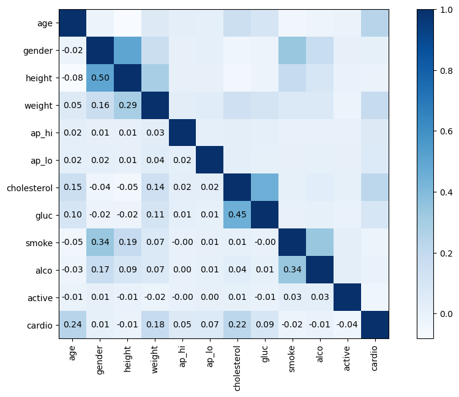

```python
# correlation matrix to visualize relationships
corr = df.corr(numeric_only=True)
mask = np.triu(np.ones_like(corr, dtype=bool))
plt.figure(figsize=(12, 7))
plt.imshow(corr, cmap='Blues')
plt.colorbar()
plt.xticks(range(len(corr.columns)), corr.columns, rotation=90)
plt.yticks(range(len(corr.columns)), corr.columns)

for i in range(len(corr)):
    for j in range(len(corr)):
        if not mask[i, j]:
            plt.text(j, i, f"{corr.iloc[i, j]:.2f}", ha='center', va='center', color='black')

plt.show()
```

```python
df.cholesterol.replace([1,2,3] ,[" normal" ,  "above normal", "well above normal"],inplace=True)
```

```python
df.gluc.replace([1,2,3] , ["normal", "above normal","well above normal"], inplace=True)
```

```python
df.smoke.replace([0,1] , ["No" , "Yes"] , inplace=True)
```

```python
df.gender.replace([1,2],["Women"  ,"Men"] , inplace=True)
```

```python
df['alco'].replace({0: "Doesn't Drink", 1: "Drink"} , inplace=True )
```

```python
df['active'].replace({0: 'Inactive', 1: 'Active'} , inplace=True )
```

```python
df['cardio'].replace({0: 'No Disease', 1: 'Has Disease'} , inplace=True )
```

```python
df.info()
```

```
<class 'pandas.core.frame.DataFrame'>
Int64Index: 70000 entries, 0 to 99999
Data columns (total 12 columns):
 #   Column       Non-Null Count  Dtype
---  ------       --------------  -----
 0   age          70000 non-null  int64
 1   gender       70000 non-null  object
 2   height       70000 non-null  int64
 3   weight       70000 non-null  float64
 4   ap_hi        70000 non-null  int64
 5   ap_lo        70000 non-null  int64
 6   cholesterol  70000 non-null  object
 7   gluc         70000 non-null  object
 8   smoke        70000 non-null  object
 9   alco         70000 non-null  object
 10  active       70000 non-null  object
 11  cardio       70000 non-null  object
dtypes: float64(1), int64(4), object(7)
memory usage: 6.9+ MB
```

```python
df
```

| id | age | gender | height | weight | ap_hi | ap_lo | cholesterol | gluc | smoke | alco | active | cardio |
| --- | --- | --- | --- | --- | --- | --- | --- | --- | --- | --- | --- | --- |
| 0 | 18393 | Men | 168 | 62.0 | 110 | 80 | normal | normal | No | Doesn't Drink | Active | No Disease |
| 1 | 20228 | Women | 156 | 85.0 | 140 | 90 | well above normal | normal | No | Doesn't Drink | Active | Has Disease |
| 2 | 18857 | Women | 165 | 64.0 | 130 | 70 | well above normal | normal | No | Doesn't Drink | Inactive | Has Disease |
| 3 | 17623 | Men | 169 | 82.0 | 150 | 100 | normal | normal | No | Doesn't Drink | Active | Has Disease |
| 4 | 17474 | Women | 156 | 56.0 | 100 | 60 | normal | normal | No | Doesn't Drink | Inactive | No Disease |
| ... | ... | ... | ... | ... | ... | ... | ... | ... | ... | ... | ... | ... |
| 99993 | 19240 | Men | 168 | 76.0 | 120 | 80 | normal | normal | Yes | Doesn't Drink | Active | No Disease |
| 99995 | 22601 | Women | 158 | 126.0 | 140 | 90 | above normal | above normal | No | Doesn't Drink | Active | Has Disease |
| 99996 | 19066 | Men | 183 | 105.0 | 180 | 90 | well above normal | normal | No | Drink | Inactive | Has Disease |
| 99998 | 22431 | Women | 163 | 72.0 | 135 | 80 | normal | above normal | No | Doesn't Drink | Inactive | Has Disease |
| 99999 | 20540 | Women | 170 | 72.0 | 120 | 80 | above normal | normal | No | Doesn't Drink | Active | No Disease |

70000 rows × 12 columns

```python
# number of unique values
df.nunique()
```

```
age            8076
gender            2
height          109
weight          287
ap_hi           153
ap_lo           157
cholesterol       3
gluc              3
smoke             2
alco              2
active            2
cardio            2
dtype: int64
```

```python
df.ap_hi.describe()
```

```
count    70000.000000
mean       128.817286
std        154.011419
min       -150.000000
25%        120.000000
50%        120.000000
75%        140.000000
max      16020.000000
Name: ap_hi, dtype: float64
```

```python
df[df.ap_hi < 0]
```

| id | age | gender | height | weight | ap_hi | ap_lo | cholesterol | gluc | smoke | alco | active | cardio |
| --- | --- | --- | --- | --- | --- | --- | --- | --- | --- | --- | --- | --- |
| 6525 | 15281 | Women | 165 | 78.0 | -100 | 80 | above normal | normal | No | Doesn't Drink | Active | No Disease |
| 22881 | 22108 | Men | 161 | 90.0 | -115 | 70 | normal | normal | No | Doesn't Drink | Active | No Disease |
| 29313 | 15581 | Women | 153 | 54.0 | -100 | 70 | normal | normal | No | Doesn't Drink | Active | No Disease |
| 34295 | 18301 | Women | 162 | 74.0 | -140 | 90 | normal | normal | No | Doesn't Drink | Active | Has Disease |
| 36025 | 14711 | Men | 168 | 50.0 | -120 | 80 | above normal | normal | No | Doesn't Drink | Inactive | Has Disease |
| 50055 | 23325 | Men | 168 | 59.0 | -150 | 80 | normal | normal | No | Doesn't Drink | Active | Has Disease |
| 66571 | 23646 | Men | 160 | 59.0 | -120 | 80 | normal | normal | No | Doesn't Drink | Inactive | No Disease |

```python
df.ap_lo.describe()
```

```
count    70000.000000
mean        96.630414
std        188.472530
min        -70.000000
25%         80.000000
50%         80.000000
75%         90.000000
max      11000.000000
Name: ap_lo, dtype: float64
```

```python
df[df.ap_lo < 0]
```

| id | age | gender | height | weight | ap_hi | ap_lo | cholesterol | gluc | smoke | alco | active | cardio |
| --- | --- | --- | --- | --- | --- | --- | --- | --- | --- | --- | --- | --- |
| 85816 | 22571 | Women | 167 | 74.0 | 15 | -70 | normal | normal | No | Doesn't Drink | Active | Has Disease |

```python
df= df[(df['ap_hi'] >= 0) & (df['ap_lo'] >= 0)]
data= data[(data['ap_hi'] >= 0) & (data['ap_lo'] >= 0)]
```

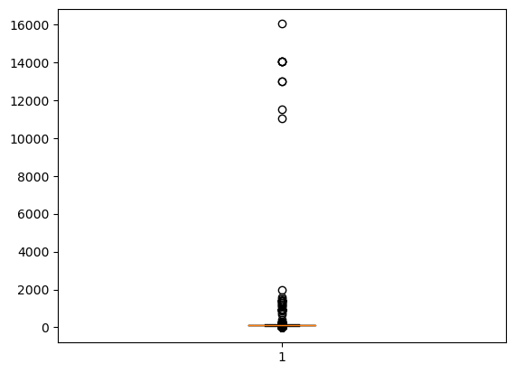

```python
plt.boxplot(df.ap_hi);
```

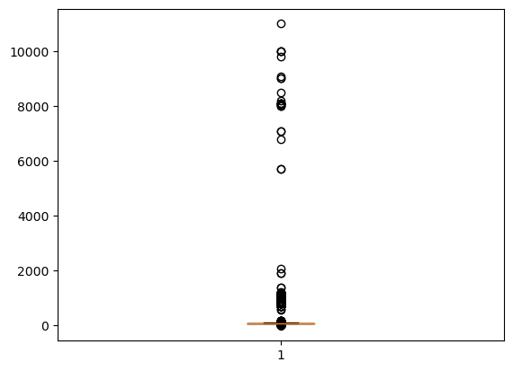

```python
plt.boxplot(df.ap_lo);
```

```python
df[df.ap_lo > 180].sort_values(by="ap_lo")["ap_lo"]
```

```
id
54282      182
70400      190
91264      190
91933      585
99006      602
         ...
62058     9800
3352     10000
34098    10000
97907    10000
61901    11000
Name: ap_lo, Length: 956, dtype: int64
```

```python
df[df.ap_hi >220].sort_values(by="ap_hi")["ap_hi"].head(11)
```

```
id
63928    230
96686    240
79903    240
61041    240
99019    240
46495    240
42394    240
37198    240
57646    309
58349    401
13616    701
Name: ap_hi, dtype: int64
```

```python
df[df.ap_hi >20].sort_values(by="ap_hi")["ap_hi"]
```

```
id
75399       24
19634       60
55291       70
58065       70
19520       70
         ...
36339    14020
67502    14020
66998    14020
36414    14020
58374    16020
Name: ap_hi, Length: 69813, dtype: int64
```

### Observations

Systolic blood pressure less than 25 mmHg is not possible in a medical condition.

```python
# removing outliers
df=df[ (df.ap_lo <=190)  & (df.ap_hi > 25)& (df.ap_hi <= 240) ]
data=data[ (data.ap_lo <=190)  & (data.ap_hi > 25)& (data.ap_hi <= 240) ]
```

```python
df
```

| id | age | gender | height | weight | ap_hi | ap_lo | cholesterol | gluc | smoke | alco | active | cardio |
| --- | --- | --- | --- | --- | --- | --- | --- | --- | --- | --- | --- | --- |
| 0 | 18393 | Men | 168 | 62.0 | 110 | 80 | normal | normal | No | Doesn't Drink | Active | No Disease |
| 1 | 20228 | Women | 156 | 85.0 | 140 | 90 | well above normal | normal | No | Doesn't Drink | Active | Has Disease |
| 2 | 18857 | Women | 165 | 64.0 | 130 | 70 | well above normal | normal | No | Doesn't Drink | Inactive | Has Disease |
| 3 | 17623 | Men | 169 | 82.0 | 150 | 100 | normal | normal | No | Doesn't Drink | Active | Has Disease |
| 4 | 17474 | Women | 156 | 56.0 | 100 | 60 | normal | normal | No | Doesn't Drink | Inactive | No Disease |
| ... | ... | ... | ... | ... | ... | ... | ... | ... | ... | ... | ... | ... |
| 99993 | 19240 | Men | 168 | 76.0 | 120 | 80 | normal | normal | Yes | Doesn't Drink | Active | No Disease |
| 99995 | 22601 | Women | 158 | 126.0 | 140 | 90 | above normal | above normal | No | Doesn't Drink | Active | Has Disease |
| 99996 | 19066 | Men | 183 | 105.0 | 180 | 90 | well above normal | normal | No | Drink | Inactive | Has Disease |
| 99998 | 22431 | Women | 163 | 72.0 | 135 | 80 | normal | above normal | No | Doesn't Drink | Inactive | Has Disease |
| 99999 | 20540 | Women | 170 | 72.0 | 120 | 80 | above normal | normal | No | Doesn't Drink | Active | No Disease |

68822 rows × 12 columns

```python
df.shape
```

```
(68822, 12)
```

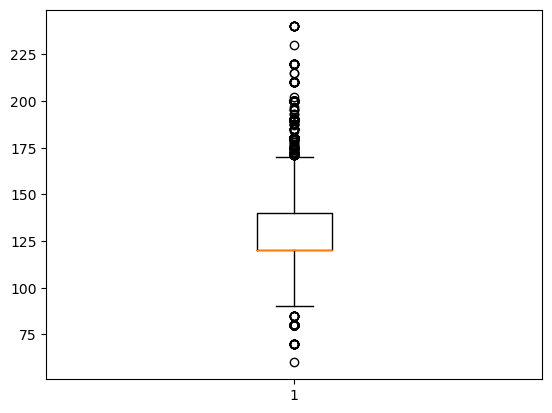

```python
plt.boxplot(df.ap_hi);
```

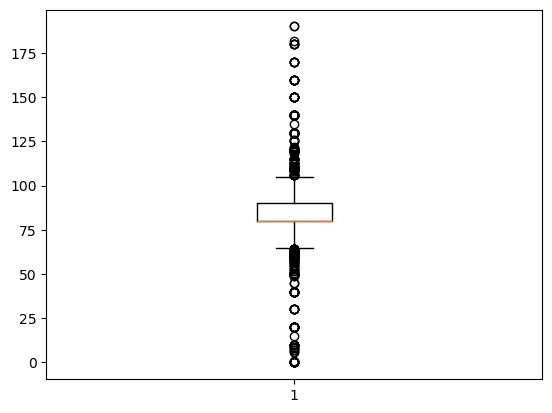

```python
plt.boxplot(df.ap_lo);
```

### Observations

When diastolic blood pressure falls below 20 mmHg, it indicates a serious condition that lead to dangerously blood pressure (heart failure, major blood loss, extreme dehydration, sepsis). When diastolic blood pressure exceeds 120-130 mmHg, it indicates severe health issues (hypertensive crises during heart attacks, Cushing's syndrome (with high cortisol), adrenal tumors (pheochromocytoma), acute kidney disease, severe atherosclerosis, and congestive heart failure. In extreme situations, diastolic pressure may reach 190 mmHg or higher, signaling a critical medical emergency requiring immediate attention.

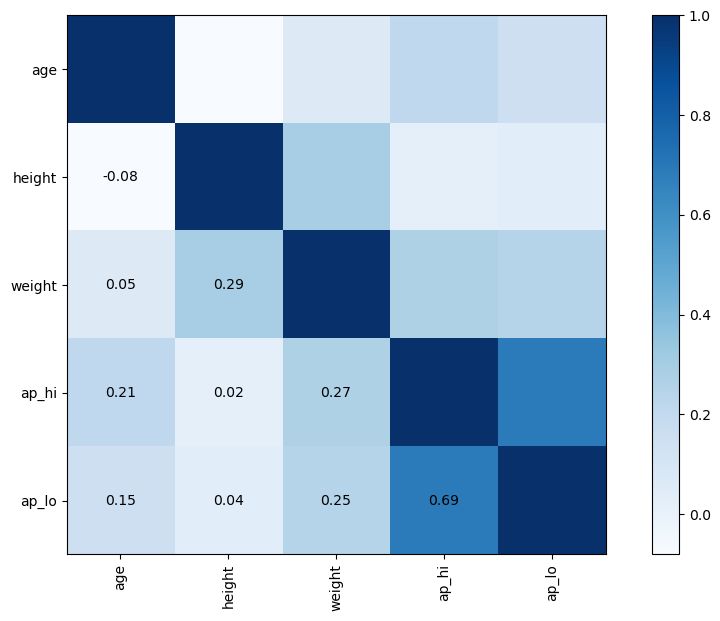

```python
corr = df.corr(numeric_only=True)
mask = np.triu(np.ones_like(corr, dtype=bool))
plt.figure(figsize=(12, 7))
plt.imshow(corr, cmap='Blues')
plt.colorbar()
plt.xticks(range(len(corr.columns)), corr.columns, rotation=90)
plt.yticks(range(len(corr.columns)), corr.columns)

for i in range(len(corr)):
    for j in range(len(corr)):
        if not mask[i, j]:
            plt.text(j, i, f"{corr.iloc[i, j]:.2f}", ha='center', va='center', color='black')

plt.show()
```

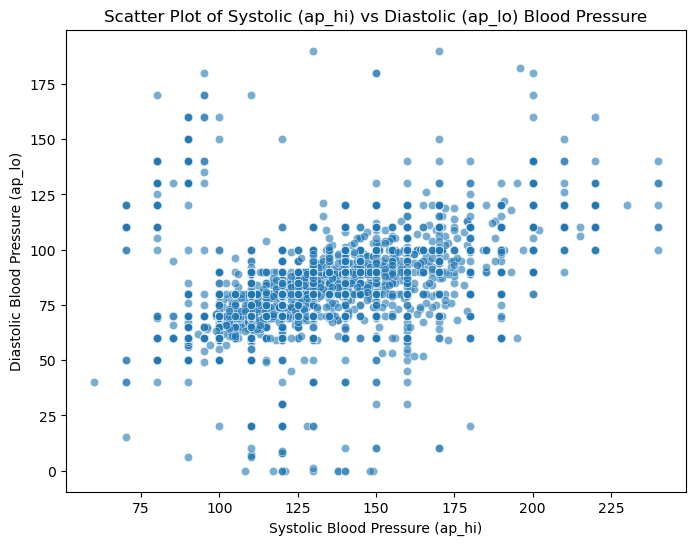

```python
plt.figure(figsize=(8,6))
sns.scatterplot(x="ap_hi", y="ap_lo", data=df,  alpha=0.6)

plt.title("Scatter Plot of Systolic (ap_hi) vs Diastolic (ap_lo) Blood Pressure")
plt.xlabel("Systolic Blood Pressure (ap_hi)")
plt.ylabel("Diastolic Blood Pressure (ap_lo)")
```

```python
correlation = df[['ap_hi', 'ap_lo']].corr().iloc[0, 1]
print(f"The correlation coefficient between ap_hi and ap_lo is: {correlation:.2f}")
```

```
The correlation coefficient between ap_hi and ap_lo is: 0.69
```

```python
def categorize_blood_pressure(ap_hi, ap_lo):
    if ap_hi < 120 and ap_lo < 80:
        return 'Normal'
    elif 120 <= ap_hi < 140 or 80 <= ap_lo < 90:
        return 'Prehypertension'
    elif 140 <= ap_hi < 160 or 90 <= ap_lo < 100:
        return 'Hypertension Stage 1'
    elif 160 <= ap_hi or ap_lo >= 100:
        return 'Hypertension Stage 2'
    elif ap_hi >= 180 or ap_lo >= 120:
        return 'Hypertensive Crisis'

df['blood_pressure_category'] = df.apply(lambda row: categorize_blood_pressure(row['ap_hi'], row['ap_lo']), axis=1)
df[['ap_hi', 'ap_lo', 'blood_pressure_category']].head(10)
```

| id | ap_hi | ap_lo | blood_pressure_category |
| --- | --- | --- | --- |
| 0 | 110 | 80 | Prehypertension |
| 1 | 140 | 90 | Hypertension Stage 1 |
| 2 | 130 | 70 | Prehypertension |
| 3 | 150 | 100 | Hypertension Stage 1 |
| 4 | 100 | 60 | Normal |
| 8 | 120 | 80 | Prehypertension |
| 9 | 130 | 80 | Prehypertension |
| 12 | 130 | 90 | Prehypertension |
| 13 | 110 | 70 | Normal |
| 14 | 110 | 60 | Normal |

```python
df['age_years'] = (df['age'] / 365).round().astype(int)
print(df)
```

```
         age gender  height  weight  ap_hi  ap_lo        cholesterol  \
id
0      18393    Men     168    62.0    110     80             normal
1      20228  Women     156    85.0    140     90  well above normal
2      18857  Women     165    64.0    130     70  well above normal
3      17623    Men     169    82.0    150    100             normal
4      17474  Women     156    56.0    100     60             normal
...      ...    ...     ...     ...    ...    ...                ...
99993  19240    Men     168    76.0    120     80             normal
99995  22601  Women     158   126.0    140     90       above normal
99996  19066    Men     183   105.0    180     90  well above normal
99998  22431  Women     163    72.0    135     80             normal
99999  20540  Women     170    72.0    120     80       above normal

               gluc smoke           alco    active       cardio  \
```

[output cut: 28 more lines]

```python
df['age_years']
```

```
id
0        50
1        55
2        52
3        48
4        48
         ..
99993    53
99995    62
99996    52
99998    61
99999    56
Name: age_years, Length: 68822, dtype: int32
```

```python
df['age_years'].describe()
```

```
count    68822.000000
mean        53.325884
std          6.767891
min         30.000000
25%         48.000000
50%         54.000000
75%         58.000000
max         65.000000
Name: age_years, dtype: float64
```

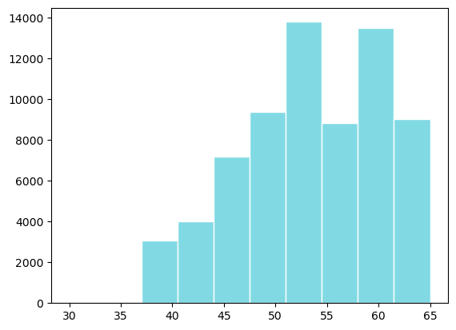

```python
df['age_years'].hist(edgecolor="white",grid=False, color="#81DAE3")
```

```python
df[df['age_years'] == df['age_years'].max()]
```

| id | age | gender | height | weight | ap_hi | ap_lo | cholesterol | gluc | smoke | alco | active | cardio | blood_pressure_category | age_years |
| --- | --- | --- | --- | --- | --- | --- | --- | --- | --- | --- | --- | --- | --- | --- |
| 95 | 23589 | Women | 155 | 57.0 | 120 | 80 | normal | normal | No | Doesn't Drink | Active | Has Disease | Prehypertension | 65 |
| 422 | 23613 | Men | 181 | 99.0 | 130 | 90 | normal | normal | No | Doesn't Drink | Active | Has Disease | Prehypertension | 65 |
| 563 | 23661 | Men | 160 | 78.0 | 140 | 90 | normal | normal | No | Doesn't Drink | Active | No Disease | Hypertension Stage 1 | 65 |
| 797 | 23578 | Women | 157 | 69.0 | 110 | 90 | normal | above normal | No | Doesn't Drink | Active | No Disease | Hypertension Stage 1 | 65 |
| 921 | 23653 | Women | 154 | 79.0 | 130 | 80 | normal | normal | No | Doesn't Drink | Active | No Disease | Prehypertension | 65 |
| ... | ... | ... | ... | ... | ... | ... | ... | ... | ... | ... | ... | ... | ... | ... |
| 98749 | 23677 | Women | 169 | 70.0 | 120 | 80 | well above normal | well above normal | No | Doesn't Drink | Active | Has Disease | Prehypertension | 65 |
| 98888 | 23546 | Women | 170 | 90.0 | 120 | 80 | normal | normal | No | Doesn't Drink | Active | No Disease | Prehypertension | 65 |
| 99066 | 23578 | Women | 168 | 64.0 | 120 | 80 | normal | normal | No | Doesn't Drink | Inactive | Has Disease | Prehypertension | 65 |
| 99517 | 23620 | Men | 168 | 74.0 | 120 | 80 | normal | normal | No | Doesn't Drink | Inactive | No Disease | Prehypertension | 65 |
| 99785 | 23646 | Women | 149 | 49.0 | 115 | 75 | normal | normal | No | Doesn't Drink | Active | No Disease | Normal | 65 |

344 rows × 14 columns

```python
df[df['age_years'] ==df['age_years'].min()]
```

| id | age | gender | height | weight | ap_hi | ap_lo | cholesterol | gluc | smoke | alco | active | cardio | blood_pressure_category | age_years |
| --- | --- | --- | --- | --- | --- | --- | --- | --- | --- | --- | --- | --- | --- | --- |
| 8850 | 10878 | Women | 175 | 59.0 | 120 | 80 | normal | normal | No | Doesn't Drink | Active | No Disease | Prehypertension | 30 |
| 31922 | 10798 | Men | 175 | 92.0 | 100 | 60 | normal | normal | No | Doesn't Drink | Active | No Disease | Normal | 30 |
| 43842 | 10859 | Women | 159 | 59.0 | 120 | 80 | normal | normal | No | Doesn't Drink | Active | No Disease | Prehypertension | 30 |
| 79749 | 10964 | Women | 160 | 59.0 | 110 | 70 | normal | normal | No | Doesn't Drink | Active | No Disease | Normal | 30 |

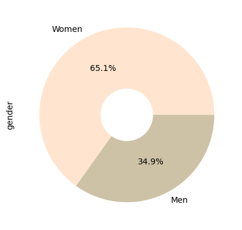

```python
df.gender.value_counts().plot(kind ="pie" , autopct='%1.1f%%', colors=["#FFE5CF" , "#CDC2A5"], explode=(0,0), wedgeprops=dict(width=0.7));
```

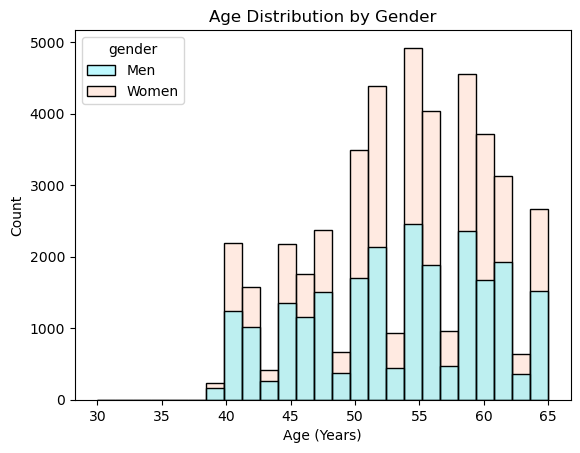

```python
sns.histplot(data=df, x='age_years', hue='gender', kde=False, bins=25, palette=["#7CF5FF" ,"#FFD7C4"])

plt.title('Age Distribution by Gender')
plt.xlabel('Age (Years)')
plt.ylabel('Count')
```

BMI = mass(kg) / (height) ^ 2(m)

```python
df['Bmi'] = round( df['weight'] / ((df['height'] / 100) ** 2) , 2)
```

```python
df.Bmi
```

```
id
0        21.97
1        34.93
2        23.51
3        28.71
4        23.01
         ...
99993    26.93
99995    50.47
99996    31.35
99998    27.10
99999    24.91
Name: Bmi, Length: 68822, dtype: float64
```

```python
df.Bmi.describe()
```

```
count    68822.000000
mean        27.524003
std          6.066779
min          3.470000
25%         23.880000
50%         26.350000
75%         30.120000
max        298.670000
Name: Bmi, dtype: float64
```

```python
df[['Bmi', 'weight', 'height']].corr()
```

|  | Bmi | weight | height |
| --- | --- | --- | --- |
| Bmi | 1.000000 | 0.761806 | -0.289969 |
| weight | 0.761806 | 1.000000 | 0.291552 |
| height | -0.289969 | 0.291552 | 1.000000 |

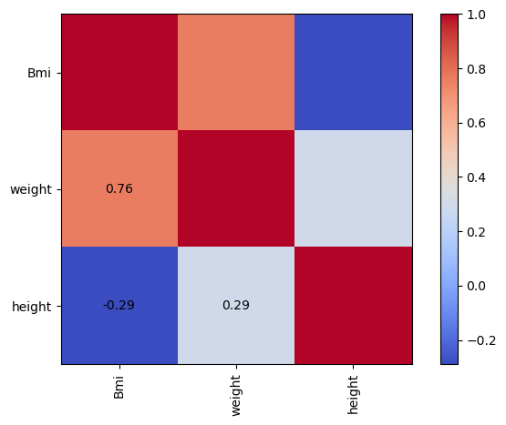

```python
# display the correlation matrix between the columns 'Bmi', 'weight', and 'height'

# sns.heatmap(df[['Bmi', 'weight', 'height']].corr() , annot=True, fmt=".1f")

corr = df[['Bmi', 'weight', 'height']].corr(numeric_only=True)
mask = np.triu(np.ones_like(corr, dtype=bool))
plt.figure(figsize=(8, 5))
plt.imshow(corr, cmap='coolwarm')
plt.colorbar()
plt.xticks(range(len(corr.columns)), corr.columns, rotation=90)
plt.yticks(range(len(corr.columns)), corr.columns)

for i in range(len(corr)):
    for j in range(len(corr)):
        if not mask[i, j]:
            plt.text(j, i, f"{corr.iloc[i, j]:.2f}", ha='center', va='center', color='black')

plt.show()
```

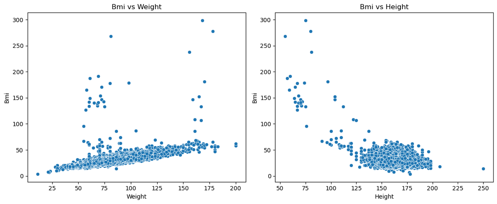

```python
plt.figure(figsize=(12, 5))

plt.subplot(1, 2, 1)
sns.scatterplot(x='weight', y='Bmi', data=df)
plt.title('Bmi vs Weight')
plt.xlabel('Weight')
plt.ylabel('Bmi')
plt.subplot(1, 2, 2)
sns.scatterplot(x='height', y='Bmi', data=df)
plt.title('Bmi vs Height')
plt.xlabel('Height')
plt.ylabel('Bmi')


plt.tight_layout()
plt.show()
```

```python
def categorize_bmi(bmi):
    if bmi < 18.5:
        return 'Wightloss'
    elif 18.5 <= bmi < 25:
        return 'Normal'
    elif 25 <= bmi < 30:
        return 'Overwight'
    elif 30 <= bmi < 35:
        return 'Obesity class 1'
    elif 35<= bmi < 40:
        return 'Obesity class 2'
    else:
        return 'Extreme Obesity'

df['BMI_category'] = df['Bmi'].apply(categorize_bmi)
```

```python
df['BMI_category']
```

```
id
0                 Normal
1        Obesity class 1
2                 Normal
3              Overwight
4                 Normal
              ...
99993          Overwight
99995    Extreme Obesity
99996    Obesity class 1
99998          Overwight
99999             Normal
Name: BMI_category, Length: 68822, dtype: object
```

```python
df['BMI_category'].unique()
```

```
array(['Normal', 'Obesity class 1', 'Overwight', 'Obesity class 2',
       'Wightloss', 'Extreme Obesity'], dtype=object)
```

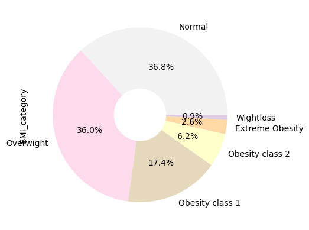

```python
colors = plt.get_cmap('Pastel1_r').colors
df.BMI_category.value_counts().plot(kind ="pie" , autopct='%1.1f%%', colors=colors, explode=(0,0,0,0,0,0), wedgeprops=dict(width=0.7));
```

```python
df_grouped = df.groupby("blood_pressure_category")["BMI_category"].value_counts()
df_grouped
```

```
blood_pressure_category  BMI_category
Hypertension Stage 1     Overwight           4676
                         Obesity class 1     3103
                         Normal              3007
                         Obesity class 2     1222
                         Extreme Obesity      556
                         Wightloss             54
Hypertension Stage 2     Overwight            861
                         Obesity class 1      715
                         Normal               468
                         Obesity class 2      370
                         Extreme Obesity      211
                         Wightloss              7
Normal                   Normal              4751
                         Overwight           3096
                         Obesity class 1     1102
                         Obesity class 2      276
                         Wightloss            255
                         Extreme Obesity       89
Prehypertension          Normal             17117
                         Overwight          16141
                         Obesity class 1     7072
                         Obesity class 2     2389
                         Extreme Obesity      963
                         Wightloss            321
Name: BMI_category, dtype: int64
```

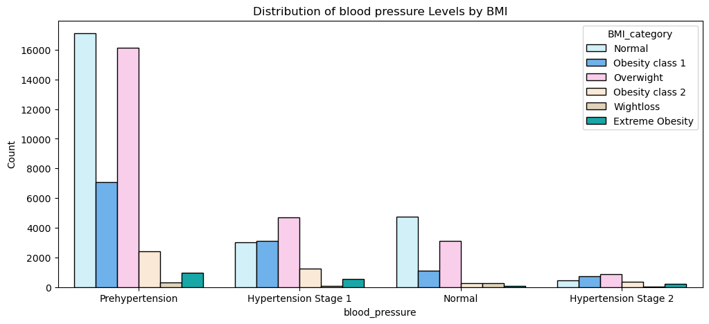

```python
plt.figure(figsize=(12,5))
sns.countplot(x="blood_pressure_category", hue="BMI_category", data=df, palette=["#CAF4FF", "#5AB2FF","#FFC7ED" ,"#FFE9D0" ,"#E7D4B5","c"] , edgecolor="black"
)

plt.title("Distribution of blood pressure Levels by BMI")
plt.xlabel("blood_pressure")
plt.ylabel("Count")


plt.show()
```

```python
df.cholesterol.value_counts()
```

```
 normal              51614
above normal          9317
well above normal     7891
Name: cholesterol, dtype: int64
```

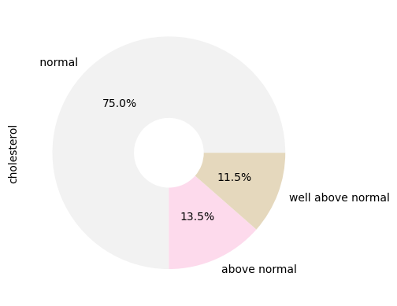

```python
colors = plt.get_cmap('Pastel1_r').colors
df.cholesterol.value_counts().plot(kind ="pie" , autopct='%1.1f%%', colors=colors, explode=(0,0,0), wedgeprops=dict(width=0.7));
```

### Observations

Cholesterol levels has hree categories: Normal, Above normal and Well above normal. The last one may lead to a serious risk for heart disease and needs medical treatment or lifestyle adjustments.

```python
df_grouped = df.groupby("cholesterol")["BMI_category"].value_counts()
df_grouped
```

```
cholesterol        BMI_category
 normal            Normal             20872
                   Overwight          18634
                   Obesity class 1     7921
                   Obesity class 2     2581
                   Extreme Obesity     1077
                   Wightloss            529
above normal       Overwight           3451
                   Normal              2580
                   Obesity class 1     2078
                   Obesity class 2      794
                   Extreme Obesity      340
                   Wightloss             74
well above normal  Overwight           2689
                   Obesity class 1     1993
                   Normal              1891
                   Obesity class 2      882
                   Extreme Obesity      402
                   Wightloss             34
Name: BMI_category, dtype: int64
```

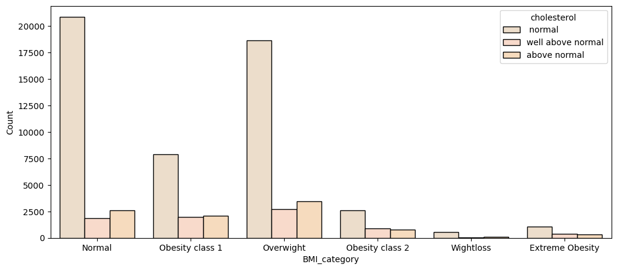

```python
plt.figure(figsize=(12,5))
sns.countplot(x="BMI_category", hue="cholesterol", data=df, palette=["#F1DEC6" , "#FFD7C4","#FFDBB5"],edgecolor="black"
)

plt.xlabel("BMI_category")
plt.ylabel("Count")
plt.show()
```

```python
df_grouped = df.groupby("cholesterol")["BMI_category"].value_counts()
df_grouped
```

```
cholesterol        BMI_category
 normal            Normal             20872
                   Overwight          18634
                   Obesity class 1     7921
                   Obesity class 2     2581
                   Extreme Obesity     1077
                   Wightloss            529
above normal       Overwight           3451
                   Normal              2580
                   Obesity class 1     2078
                   Obesity class 2      794
                   Extreme Obesity      340
                   Wightloss             74
well above normal  Overwight           2689
                   Obesity class 1     1993
                   Normal              1891
                   Obesity class 2      882
                   Extreme Obesity      402
                   Wightloss             34
Name: BMI_category, dtype: int64
```

```python
df.gluc.value_counts()
```

```
normal               58510
well above normal     5236
above normal          5076
Name: gluc, dtype: int64
```

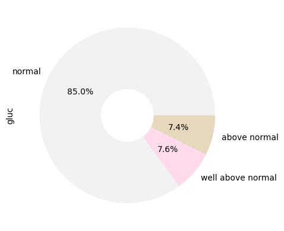

```python
colors = plt.get_cmap('Pastel1_r').colors
df.gluc.value_counts().plot(kind ="pie" , autopct='%1.1f%%', colors=colors, explode=(0,0,0), wedgeprops=dict(width=0.7));
```

### Observations

Blood glucose levels: Normal, Above normal (pre-diabetes) and Well above normal (diabetes) that require urgent medical attention.

```python
data[["gluc" , "cholesterol"]].corr(numeric_only=True)
```

|  | gluc | cholesterol |
| --- | --- | --- |
| gluc | 1.000000 | 0.451103 |
| cholesterol | 0.451103 | 1.000000 |

```python
df.groupby("gluc")["cholesterol"].value_counts()
```

```
gluc               cholesterol
above normal       above normal          2375
                    normal               2199
                   well above normal      502
normal              normal              47951
                   above normal          6571
                   well above normal     3988
well above normal  well above normal     3401
                    normal               1464
                   above normal           371
Name: cholesterol, dtype: int64
```

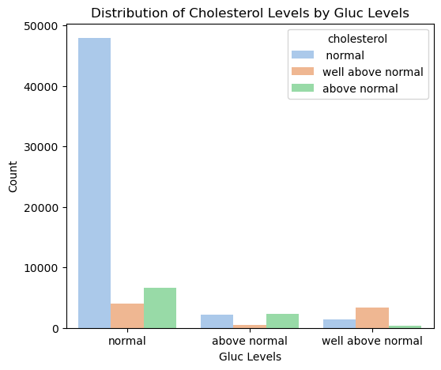

```python
plt.figure(figsize=(6,5))
sns.countplot(x="gluc", hue="cholesterol", data=df, palette="pastel")

plt.title("Distribution of Cholesterol Levels by Gluc Levels")
plt.xlabel("Gluc Levels")
plt.ylabel("Count")
plt.show()
```

```python
df.groupby(["gender" , "gluc"])["cholesterol"].value_counts()
```

```
gender  gluc               cholesterol
Men     above normal        normal                827
                           above normal           747
                           well above normal      150
        normal              normal              17150
                           above normal          2175
                           well above normal     1301
        well above normal  well above normal      991
                            normal                532
                           above normal           128
Women   above normal       above normal          1628
                            normal               1372
                           well above normal      352
        normal              normal              30801
                           above normal          4396
                           well above normal     2687
        well above normal  well above normal     2410
                            normal                932
                           above normal           243
Name: cholesterol, dtype: int64
```

```python
df.smoke.value_counts()
```

```
No     62767
Yes     6055
Name: smoke, dtype: int64
```

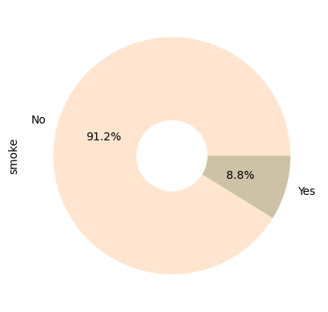

```python
df.smoke.value_counts().plot(kind ="pie" , autopct='%1.1f%%', colors=["#FFE5CF" , "#CDC2A5"], explode=(0,0), wedgeprops=dict(width=0.7));
```

```python
df.groupby("gender")["smoke"].value_counts()
```

```
gender  smoke
Men     No       18742
        Yes       5259
Women   No       44025
        Yes        796
Name: smoke, dtype: int64
```

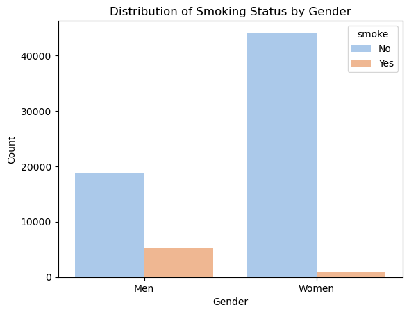

```python
sns.countplot(x="gender", hue="smoke", data=df, palette="pastel")

plt.title("Distribution of Smoking Status by Gender")
plt.xlabel("Gender")
plt.ylabel("Count")
plt.show()
```

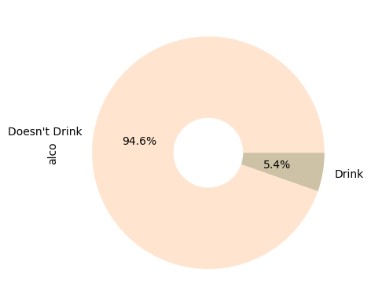

```python
df.alco.value_counts().plot(kind ="pie" , autopct='%1.1f%%', colors=["#FFE5CF" , "#CDC2A5"], explode=(0,0), wedgeprops=dict(width=0.7));
```

```python
data[["alco" , "smoke"]].corr()
```

|  | alco | smoke |
| --- | --- | --- |
| alco | 1.000000 | 0.339997 |
| smoke | 0.339997 | 1.000000 |

```python
df.groupby("smoke")["alco"].value_counts()
```

```
smoke  alco
No     Doesn't Drink    60894
       Drink             1873
Yes    Doesn't Drink     4237
       Drink             1818
Name: alco, dtype: int64
```

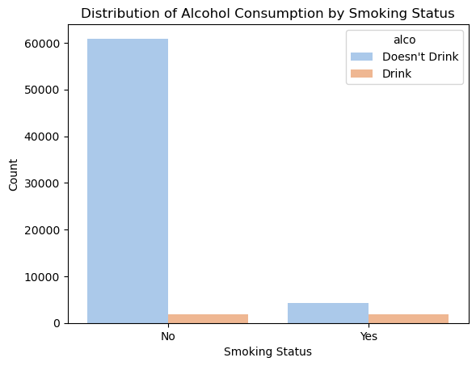

```python
sns.barplot(x="smoke", y="count", hue="alco", data=df.groupby(["smoke", "alco"]).size().reset_index(name='count'), palette="pastel")

plt.title("Distribution of Alcohol Consumption by Smoking Status")
plt.xlabel("Smoking Status")
plt.ylabel("Count");
```

```python
smoke_drink = df[ (df["smoke"]=="Yes") &  (df["alco"]=="Drink") ]
smoke_drink
```

| id | age | gender | height | weight | ap_hi | ap_lo | cholesterol | gluc | smoke | alco | active | cardio | blood_pressure_category | age_years | Bmi | BMI_category |
| --- | --- | --- | --- | --- | --- | --- | --- | --- | --- | --- | --- | --- | --- | --- | --- | --- |
| 23 | 14532 | Men | 181 | 95.0 | 130 | 90 | normal | normal | Yes | Drink | Active | No Disease | Prehypertension | 40 | 29.00 | Overwight |
| 142 | 14499 | Men | 164 | 48.0 | 110 | 70 | normal | above normal | Yes | Drink | Active | Has Disease | Normal | 40 | 17.85 | Wightloss |
| 180 | 21473 | Men | 174 | 90.0 | 140 | 80 | normal | normal | Yes | Drink | Inactive | Has Disease | Prehypertension | 59 | 29.73 | Overwight |
| 240 | 21848 | Men | 170 | 69.0 | 120 | 80 | normal | normal | Yes | Drink | Active | No Disease | Prehypertension | 60 | 23.88 | Normal |
| 318 | 23376 | Men | 175 | 75.0 | 180 | 100 | well above normal | normal | Yes | Drink | Active | Has Disease | Hypertension Stage 2 | 64 | 24.49 | Normal |
| ... | ... | ... | ... | ... | ... | ... | ... | ... | ... | ... | ... | ... | ... | ... | ... | ... |
| 99779 | 17256 | Men | 173 | 70.0 | 130 | 80 | normal | normal | Yes | Drink | Active | No Disease | Prehypertension | 47 | 23.39 | Normal |
| 99858 | 19475 | Men | 171 | 65.0 | 120 | 80 | normal | normal | Yes | Drink | Active | No Disease | Prehypertension | 53 | 22.23 | Normal |
| 99933 | 19137 | Men | 167 | 74.0 | 130 | 80 | normal | normal | Yes | Drink | Active | No Disease | Prehypertension | 52 | 26.53 | Overwight |
| 99936 | 17373 | Men | 173 | 69.0 | 110 | 70 | normal | normal | Yes | Drink | Active | Has Disease | Normal | 48 | 23.05 | Normal |
| 99958 | 22572 | Men | 173 | 103.0 | 140 | 80 | well above normal | normal | Yes | Drink | Inactive | Has Disease | Prehypertension | 62 | 34.41 | Obesity class 1 |

1818 rows × 16 columns

```python
df.active.value_counts()
```

```
Active      55292
Inactive    13530
Name: active, dtype: int64
```

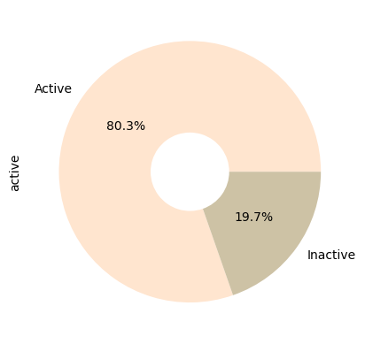

```python
df.active.value_counts().plot(kind ="pie" , autopct='%1.1f%%', colors=["#FFE5CF" , "#CDC2A5"], explode=(0,0), wedgeprops=dict(width=0.7));
```

```python
df.cardio.value_counts()
```

```
No Disease     34764
Has Disease    34058
Name: cardio, dtype: int64
```

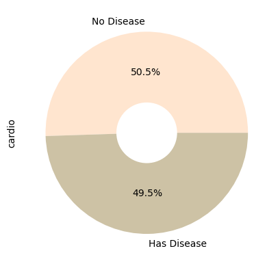

```python
df.cardio.value_counts().plot(kind ="pie" , autopct='%1.1f%%', colors=["#FFE5CF" , "#CDC2A5"], explode=(0,0), wedgeprops=dict(width=0.7));
```

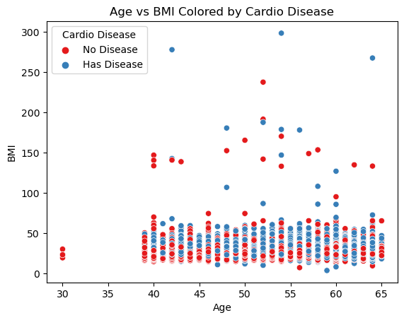

```python
sns.scatterplot(y='Bmi', x='age_years', hue='cardio', data=df, palette='Set1')

plt.title('Age vs BMI Colored by Cardio Disease')
plt.xlabel('Age')
plt.ylabel('BMI')
plt.legend(title='Cardio Disease')
plt.show()
```

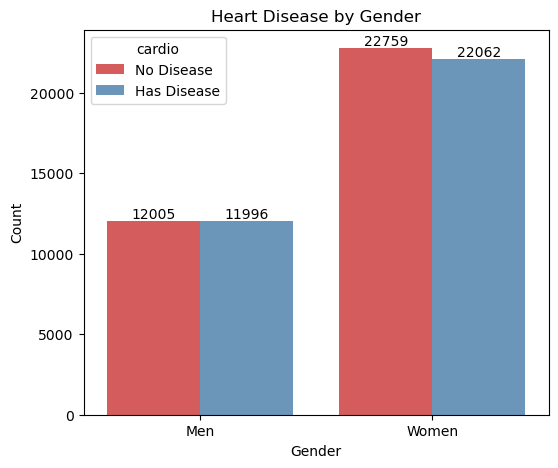

```python
plt.figure(figsize=(6,5))
axis=sns.countplot(data=df, x='gender', hue='cardio', palette='Set1' , alpha=0.8)
axis.bar_label(axis.containers[0]);
axis.bar_label(axis.containers[1]);
plt.title('Heart Disease by Gender')
plt.xlabel('Gender')
plt.ylabel('Count')
plt.show()
```

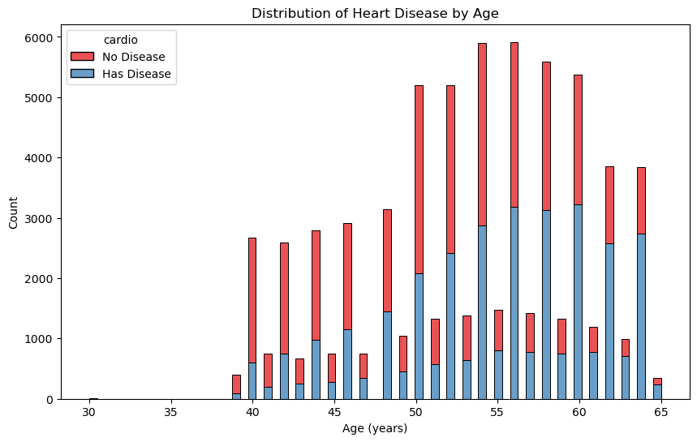

```python
plt.figure(figsize=(10,6))
sns.histplot(data=df, x='age_years', hue='cardio', multiple='stack', kde=False, palette='Set1')
plt.title('Distribution of Heart Disease by Age')
plt.xlabel('Age (years)')
plt.ylabel('Count')
plt.show()
```

```python
round( pd.crosstab(df['BMI_category'], df['cardio'], normalize='index') * 100 , 2)
```

| cardio BMI_category | Has Disease | No Disease |
| --- | --- | --- |
| Extreme Obesity | 68.17 | 31.83 |
| Normal | 39.76 | 60.24 |
| Obesity class 1 | 59.91 | 40.09 |
| Obesity class 2 | 67.23 | 32.77 |
| Overwight | 50.53 | 49.47 |
| Wightloss | 27.79 | 72.21 |

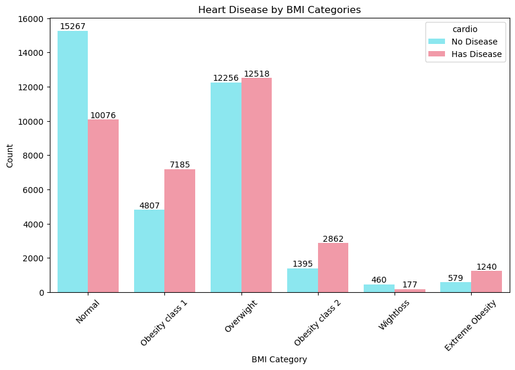

```python
plt.figure(figsize=(10,6))
axis=sns.countplot(data=df, x='BMI_category', hue='cardio', palette=["#7CF5FF" ,"#FF8C9E"])
axis.bar_label(axis.containers[0])
axis.bar_label(axis.containers[1])
plt.title('Heart Disease by BMI Categories')
plt.xlabel('BMI Category')
plt.ylabel('Count')
plt.xticks(rotation=45)
plt.show()
```

```python
round( pd.crosstab(df['blood_pressure_category'], df['cardio'], normalize='index') * 100 , 2)
```

| cardio blood_pressure_category | Has Disease | No Disease |
| --- | --- | --- |
| Hypertension Stage 1 | 82.43 | 17.57 |
| Hypertension Stage 2 | 84.73 | 15.27 |
| Normal | 22.14 | 77.86 |
| Prehypertension | 43.88 | 56.12 |

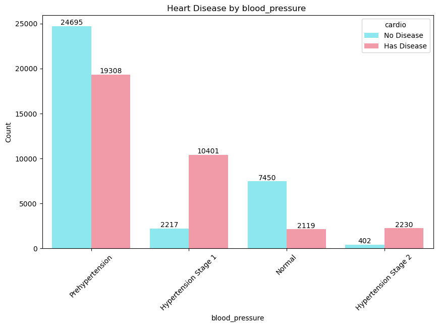

```python
plt.figure(figsize=(10,6))
axis=sns.countplot(data=df, x='blood_pressure_category', hue='cardio', palette=["#7CF5FF" ,"#FF8C9E"])
axis.bar_label(axis.containers[0])
axis.bar_label(axis.containers[1])
plt.title('Heart Disease by blood_pressure ')
plt.xlabel('blood_pressure')
plt.ylabel('Count')
plt.xticks(rotation=45)
plt.show()
```

```python
round( pd.crosstab(df['cholesterol'], df['cardio'], normalize='index') * 100 , 2)
```

| cardio cholesterol | Has Disease | No Disease |
| --- | --- | --- |
| normal | 43.56 | 56.44 |
| above normal | 59.63 | 40.37 |
| well above normal | 76.29 | 23.71 |

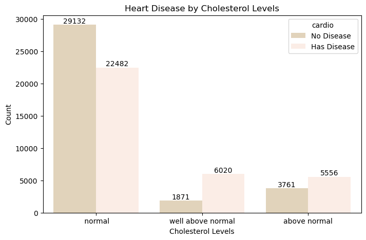

```python
plt.figure(figsize=(8,5))
axis= sns.countplot(data=df, x='cholesterol', hue='cardio', palette=["#E7D4B5" ,"#FEECE2"])
axis.bar_label(axis.containers[0])
axis.bar_label(axis.containers[1])

plt.title('Heart Disease by Cholesterol Levels')
plt.xlabel('Cholesterol Levels')
plt.ylabel('Count')
plt.show()
```

```python
round( pd.crosstab(df['gluc'], df['cardio'], normalize='index') * 100 , 2)
```

| cardio gluc | Has Disease | No Disease |
| --- | --- | --- |
| above normal | 58.87 | 41.13 |
| normal | 47.56 | 52.44 |
| well above normal | 61.88 | 38.12 |

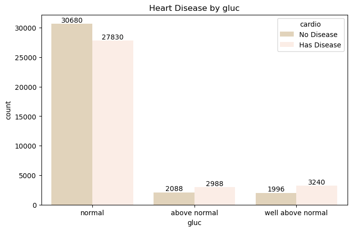

```python
plt.figure(figsize=(8,5))
axis= sns.countplot(data=df, x='gluc', hue='cardio', palette=["#E7D4B5" ,"#FEECE2"])
axis.bar_label(axis.containers[0])
axis.bar_label(axis.containers[1])
plt.title('Heart Disease by gluc');
```

```python
df_grouped = df.groupby(["cardio", "cholesterol"])["gluc"].value_counts().reset_index(name='count')
df_grouped.set_index(['cardio' , "cholesterol","gluc"], inplace=True)

df_grouped
```

| cardio | cholesterol | gluc | count |
| --- | --- | --- | --- |
| Has Disease | normal | normal | 20632 |
|  |  | above normal | 1176 |
|  |  | well above normal | 674 |
|  | above normal | normal | 3930 |
|  |  | above normal | 1404 |
|  |  | well above normal | 222 |
|  | well above normal | normal | 3268 |
|  |  | well above normal | 2344 |
|  |  | above normal | 408 |
| No Disease | normal | normal | 27319 |
|  |  | above normal | 1023 |
|  |  | well above normal | 790 |
|  | above normal | normal | 2641 |
|  |  | above normal | 971 |
|  |  | well above normal | 149 |
|  | well above normal | well above normal | 1057 |
|  |  | normal | 720 |
|  |  | above normal | 94 |

```python
round( pd.crosstab(df['smoke'], df['cardio'], normalize='index') * 100 , 2)
```

| cardio smoke | Has Disease | No Disease |
| --- | --- | --- |
| No | 49.74 | 50.26 |
| Yes | 46.87 | 53.13 |

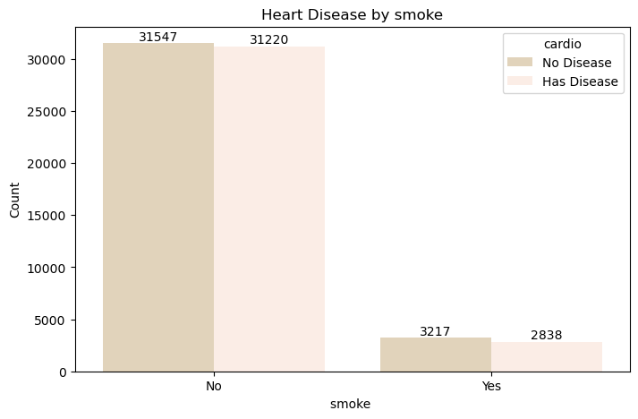

```python
plt.figure(figsize=(8,5))
axis= sns.countplot(data=df, x='smoke', hue='cardio', palette=["#E7D4B5" ,"#FEECE2"])
axis.bar_label(axis.containers[0]);
axis.bar_label(axis.containers[1]);

plt.title('Heart Disease by smoke')
plt.xlabel('smoke ')
plt.ylabel('Count')
plt.show()
```

```python
df_grouped = df.groupby(["cardio", "smoke"])["alco"].value_counts().reset_index(name='count')
df_grouped.set_index(['cardio', 'smoke',"alco"], inplace=True)

df_grouped
```

| cardio | smoke | alco | count |
| --- | --- | --- | --- |
| Has Disease | No | Doesn't Drink | 30255 |
|  |  | Drink | 965 |
|  | Yes | Doesn't Drink | 2039 |
|  |  | Drink | 799 |
| No Disease | No | Doesn't Drink | 30639 |
|  |  | Drink | 908 |
|  | Yes | Doesn't Drink | 2198 |
|  |  | Drink | 1019 |

```python
round( pd.crosstab(df['active'], df['cardio'], normalize='index') * 100 , 2)
```

| cardio active | Has Disease | No Disease |
| --- | --- | --- |
| Active | 48.57 | 51.43 |
| Inactive | 53.24 | 46.76 |

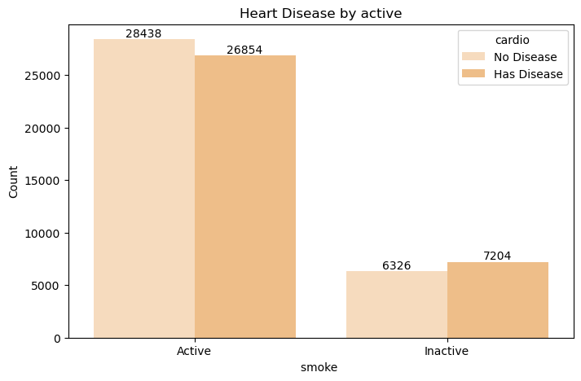

```python
plt.figure(figsize=(8,5))
axis= sns.countplot(data=df, x='active', hue='cardio', palette=["#FFDBB5", "#FFBF78"])
axis.bar_label(axis.containers[0]);
axis.bar_label(axis.containers[1]);

plt.title('Heart Disease by active')
plt.xlabel('smoke ')
plt.ylabel('Count')
plt.show()
```

# 3. Machine Learning

Classification techniques were used: Logistic Regression, Random Forest. For evaluation metrics were used: used accuracy, precision, recall, F1 score, and ROC-AUC to assess model performance. Performed cross-validation to ensure the robustness of your results. Plotted ROC curves to visualize model performance.

```python
print(df.columns)
```

```
Index(['age', 'gender', 'height', 'weight', 'ap_hi', 'ap_lo', 'cholesterol',
       'gluc', 'smoke', 'alco', 'active', 'cardio', 'blood_pressure_category',
       'age_years', 'Bmi', 'BMI_category'],
      dtype='object')
```

```python
# Prepare the data by selecting features and target variable
# Assuming 'cardio' is the target variable and other columns are features
X = df.drop('cardio', axis=1)  # Features
y = df['cardio']                # Target variable

# Split the data into training and testing sets
X_train, X_test, y_train, y_test = train_test_split(X, y, test_size=0.2, random_state=42)
```

```python
# Train the Models, both the Logistic Regression and Random Forest models.

# Logistic Regression
log_model = LogisticRegression(max_iter=1000)
log_model.fit(X_train, y_train)

# Random Forest Classifier
rf_model = RandomForestClassifier(n_estimators=100, random_state=42)
rf_model.fit(X_train, y_train)
```

```
RandomForestClassifier(random_state=42)
```

```python
# Evaluate the Models using various metrics

# Make predictions
log_predictions = log_model.predict(X_test)
rf_predictions = rf_model.predict(X_test)

# Evaluate Logistic Regression
print("Logistic Regression Evaluation:")
print("Accuracy:", accuracy_score(y_test, log_predictions))
print("Precision:", precision_score(y_test, log_predictions))
print("Recall:", recall_score(y_test, log_predictions))
print("F1 Score:", f1_score(y_test, log_predictions))

# Evaluate Random Forest
print("\nRandom Forest Evaluation:")
print("Accuracy:", accuracy_score(y_test, rf_predictions))
print("Precision:", precision_score(y_test, rf_predictions))
print("Recall:", recall_score(y_test, rf_predictions))
print("F1 Score:", f1_score(y_test, rf_predictions))
```

[output not shown]

### Observations

The Random Forest model and the Logistic Regression model show reasonable performance. It might be beneficial to explore hyperparameter tuning for both models or to try additional models, such as Support Vector Machines or XGBoost, to see if further improvements can be made.

```python
# Ensure robust of the results

# Cross-Validation for Logistic Regression
log_cv_scores = cross_val_score(log_model, X, y, cv=5, scoring='accuracy')
print("\nLogistic Regression Cross-Validation Accuracy:", log_cv_scores.mean())

# Cross-Validation for Random Forest
rf_cv_scores = cross_val_score(rf_model, X, y, cv=5, scoring='accuracy')
print("Random Forest Cross-Validation Accuracy:", rf_cv_scores.mean())
```

[output not shown]

[output not shown]